# Measuring the Extent and Patterns of Urban Shrinkage for Small Towns Using R

Urban shrinking is a phenomenon as common as urban expansion nowadays and it affects urban settlements of all sizes, especially from developed and industrialized countries in Europe, America and Asia. The paper aims to assess the patterns of shrinkage for small and medium sized towns in Oltenia region (Romania), considering demographic, economic and social indicators with a methodological approach which considers the use of different functions and applications of R packages. Thirteen selected indicators are analysed to perform the multivariate analysis on Principal Component Analysis using the `prcomp()` function and the [*ggplot2*](https://CRAN.R-project.org/package=ggplot2) package to visualize the patterns of urban shrinkage. Two composite indicators were additionally created to measure the extent of urban shrinkage: CSI (Composite Shrinking Index) and RDC (Regional Demographic Change) for two-time intervals. Based on the CSI, three major categories of shrinking were observed: persistent shrinkage, mild shrinking or slow evolution toward shrinking, where the vast majority of towns are found (including mining towns, where there still is a delayed restructuring of state-owned enterprises, and towns characterised by the agrarization of local economies), and stagnant/stabilized shrinkage.

Cristiana Vîlcea (University of Craiova) , Liliana Popescu (University of Craiova) , Alin Clincea (University of Craiova)  
2022-06-21

## 1 Introduction

Shrinking cities, considered up until recently a politically taboo subject in Europe, systematically disregarded as a dominant development trend of some urban areas (Wiechmann 2007; Nelle et al. 2017), and a stigmatized topic in planning research (Pallagst 2010), are ever more present among the research topic of various scholars throughout the world, as well as the agenda of public authorities and policy makers. Thus, the concept of shrinking cities differs from the classic notion of urban decline since new processes are at stake (Cunningham-Sabot et al. 2014).

From a historical perspective, the current period of shrinkage is distinguishable from the earlier period of decline and an earlier period of growth as well, mainly due to the prevalence of population loss, less so in its severity and not in its persistence or lack thereof (Beauregard 2013). Today, the concept of shrinking cities connotes the urban degenerative effects of the breakdown of Fordist agglomeration economies, as well as the effects of urban agglomerative and dissipative forces associated with the global diffusion of contemporary, post-Fordist systems of production (Audirac 2014).

Beginning with the 20th century, shrinking cities have developed continuously into a global phenomenon, being located mainly in Central Europe, the US, Japan and Eastern European transformation countries (Oswalt and Rieniets 2006). They tend to have a common industrial past and are now faced with large challenges as a result of economic restructuring (Urban Audit 2007). In Europe, the number of growing cities has been falling steadily since the 1960s, while almost a quarter (24%) of the cities have registered a medium-term decline (almost half of all the Russian, Polish and Romanian cities with a population over 200,000 inhabitants) and more than a third showed a clear downturn since 1990 (Turok and Mykhnenko 2007). Still, the phenomenon is not equally spread throughout Europe, some countries and regions being more affected, i.e. post socialist countries, where almost half of cities can be described as shrinking (Wiechmann and Wolff 2013), while others, such as France, experiencing a more-limited intensity in terms of number of cities affected and population loss (Wolff et al. 2013).

Since the publication of *Die Schrympfende Stadt (the Shrinking City)* (Göb 1977) and *Coping with City Shrinkage* (Breckenfeld 1978), some of the ways of understanding the city have changed in emphasis. Researchers’ efforts have focused on capturing the main features of the phenomenon due to its role in the reconfiguration of the urban space, which resulted in a substantial literature on urban shrinking that is undoubtedly an incontrovertible and increasingly important phenomenon, and a major challenge for future urban policies (Pallagst 2010; Bernt et al. 2012; Wiechmann and Wolff 2013; Wiechmann and Bontje 2015; Mallach et al. 2017; Nelle et al. 2017; Agirre-Maskariano 2019).

The last two decades saw an emergence of a corpus of research and projects designed to assess general causes and models of shrinkage. Several authors identify four to five major drivers for shrinkage, which are often found in a combination of two or more of these causes: i) suburbanization (flight of people and jobs to the suburbs, hollowing out of the core city, triggered by urban sprawl)(Wiechmann 2006; Reckien and Martinez-Fernandez 2011; Audirac 2014; Cunningham-Sabot et al. 2014; Wiechmann and Bontje 2015,), ii) economic decline and industrial transformation (Wiechmann 2006; Rink et al. 2010; Haase et al. 2014), iii) demographic change (e.g. falling birth rates, outmigration in rural depopulation areas) (Rink et al. 2010; Haase et al. 2014; Wiechmann and Bontje 2015); iv) structural upheaval (economic reorganization, collapse of an entire political system, unrest, resettlements) and environmental pollution (Wiechmann 2006; Cunningham-Sabot et al. 2014; Haase et al. 2014; Wiechmann and Bontje 2015).

Over the past decades, shrinkage has become a "normal pathway" of development for cities and regions all across Europe (Rink et al. 2010). Recent writing and research on the shrinking cities have also focused on indicators of urban shrinkage, which should be necessarily dynamic and capable of detecting medium-term tendencies, distinguishing between episodic or acute shrinkage (when developments fluctuate in a certain period, but have an overall negative evaluation) and continuous or chronic shrinking (Wolff and Wiechmann 2014). Since population loss, which is an initial clue of urban processes and a major indicator for urban shrinkage, does not encompass the various aspects of the phenomenon, there is a continuous focus on indicators to measure shrinking cities. They can be summarized into three main categories: demographic indicators, economic indicators and social indicators.

Among the demographic indicators, migration, population natural increase and a shifting population structure (ageing and feminization) are key factors of population decline, highly connected to other social, economic and built environment variables (Turok and Mykhnenko 2007; Guimarães et al. 2015; Haase et al. 2016; Cauchi-Duval et al. 2017; Bănică et al. 2017; Hartt 2018). Indicators related to economic changes (employment, unemployment, firms, services) are more difficult to gather and raise issues in terms of comparability among countries (Martinez-Fernandez et al. 2015), but should not be neglected as the economic decline is among the drivers of shrinkage. Social indicators usually considered when analysing shrinkage refer either to households (housing permit rates, housing start rate, number of households) (Bontje 2004; Wolff and Wiechmann 2014; Guimarães et al. 2015; Lauf et al. 2016; Hartt 2018), or to the number of students enrolled in education units (Guimarães et al. 2015). This decreases attractiveness of a city as an educational place. Consequently, it causes a decreasing number of students enrolled in compulsory education levels and the closure of educational institutions (Wolff and Wiechmann 2014).

Most of the studies regarding shrinking cities focus on larger urban centres, exceeding two hundred thousand inhabitants. However, many of the spatial planning and development strategies of the European Union focus on small and medium-sized towns, often seen as the chronic patients of regional policy, constantly in need of care but never getting well (Wirth et al. 2016). Most of the French shrinking cities are small urban areas, with less than 50,000 inhabitants, while in Germany the most dramatic decrease occurs in medium sized cities (Martinez-Fernandez et al. 2015). In Hungary, almost every small town has shrunk during at least the last decade (Pirisi et al. 2015). In Romania, the discussion within urban planning has also begun, despite focusing on some larger towns, researchers from various fields drawing attention to this issue (Popescu 2014; Schoenberg and Constantin 2014; Jucu et al. 2016; Bănică et al. 2017; Păun Constantinescu 2019; Jucu and Pavel 2019; Stoica et al. 2020b,a) since the Romanian towns clearly witness a decline on short or medium term, which is uneven, but in perpetuum (Păun Constantinescu 2013).

## 2 Data and methods

The multidimensional concept of shrinking cities has a comprehensive meaning, as the drivers which determine this process are complex (demographic, economic, social). Therefore official statistics from the last three censuses (1992, 2002, 2011) and from 2018 were used to calculate indicators. We applied simple standard formulae in population geography regarding the demographic and economic phenomena such as population natural increase, feminization, migration, ageing, unemployment, i.e. *k*<sub>1</sub>-*k*<sub>6</sub> and construct composite indices. All indices used in the analysis of this phenomenon were based on their importance and relationship to each other and to the concept itself. After a thorough documentation focusing on other studies referring to shrinking cities (Rink et al. 2010; Wiechmann and Wolff 2013; Wiechmann and Bontje 2015; Haase et al. 2016; Mallach et al. 2017; Hartt 2018) we selected a series of demographic and socio-economic indicators that met the criteria of availability and relevance for the study. Availability and consistency of data for small Romanian towns represented a major issue, as there are missing time series and uneven statistics. Thus, in order to perform the calculation without errors caused by missing values, authors imputed these missing values with zero, as the frequency of missingness was not high and it was observed that zero imputing does not affect the results of the study. This major issue played an important role in the selection of the best indicators considered for the multivariate analysis and the aggregation method. The chosen indicators vary in terms of measurement unit, as they are expressed as absolute or computed data (Table 1), but we also weighted their strengths and weaknesses.

Table 1: The selection of indicators used for aggregation.

| **Selected indices** | **M.U.** | **Assigned code** |
| --- | --- | --- |
| **Demographic indicators** |  |  |
| migration rate |  | $k_1$ |
| rate of natural increase |  | $k_2$ |
| feminization index | % | $k_3$ |
| elderly population | % | $k_4$ |
| mean age | % | $k_5$ |
| **Economic indicators** |  |  |
| unemployment rate | % | $k_6$ |
| employees | number | $k_7$ |
| **Social indicators** |  |  |
| households | number | $k_8$ |
| libraries | number | $k_9$ |
| doctors | number | $k_{10}$ |
| students | number | $k_{11}$ |
| education | number | $k_{12}$ |
| hospital beds | number | $k_{13}$ |

The work flow consists in several stages, the main step concentrating on the creation and use of the composite indicators (CSI and RDC) (Figure 1).

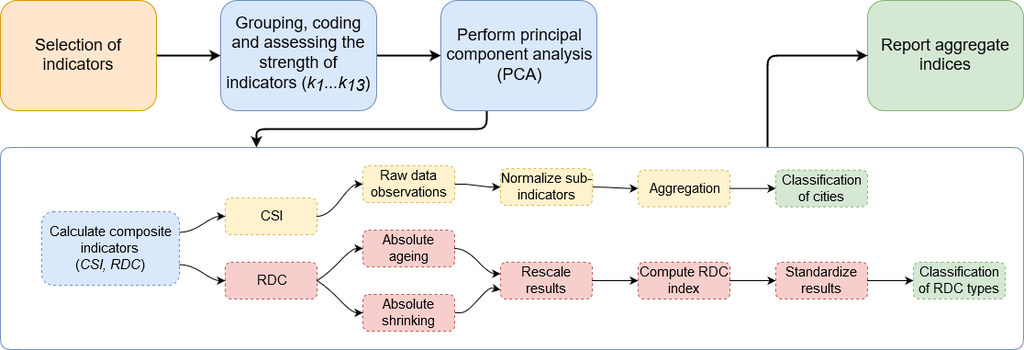

Figure 1: Overall workflow for the research methodology, depicting the main steps of the process, from the selection of indicators to the resulting aggregate indices.

As defined by OECD (2008) in the Glossary of Statistical terms *"a composite indicator is obtained from the combination of individual indicators into a single index, on the basis of an underlying model of the multidimensional concept that is being measured"*.

The study uses two types of composite indices to observe and analyse the dynamics of the shrinking process specific for the cities in the South West Development Region of Oltenia. The first composite indicator used is the Regional Demographic Change (RDC) obtained by applying the methodology described by Tivig et al. (2008) in the *Final Report of the Mapping Regional Demographic Change and Regional Demographic Location Risk in Europe*. The RDC index was initially used to describe the process of ageing and shrinking of the population in 27 European states from 264 regions. We adapted the methodology to compute this index for 34 towns located in the South West Development Region of Oltenia. The RDC index captures the extent and time-path of demographic change by accounting for two of its dimensions: population ageing with the perspective of shrinking. The RDC index is calculated using raw indicators for age, like the mean age, and population size like population density. Based on these two indicators for population age and density, the ageing and shrinking process are calculated and assessed in absolute terms for each town and three periods of time (please see research data, sheet *mean_age* and *density* for calculated data). Thus, the index was calculated for 3 time-intervals: 1992-2018; 2018-2030 and 1992-2030. In order to be able to make cross-period comparison, a rescaling was necessary. For analyzing the relative position of the towns within the region in terms of ageing and shrinking the values computed previously had been z-standardized (Tivig et al. 2008). If the RDC index shows the demographic change that takes place in the small towns under analysis, the RDC type indicate whether their population ages faster or slower and grows less or shrinks as compared to the average of the region. The four types of the RDC-index were applied to one regional dimension (South West Development Region of Oltenia) and represented showing the overall trend (1992-2030) and the future trend (2018-2030).

The second composite indicator (CSI) was created based on thirteen sub-indices (*k*<sub>1</sub>…<sub>13</sub>) computed for all 34 towns located in the study area and aggregated into a single index using the additive method (Saisana and Tarantola 2002; Nardo et al. 2005; OECD 2008; Gan et al. 2017; Syrovátka and Schlossarek 2019). The additive aggregation method, and especially the weighted arithmetic mean, is the widest used method (Pollesch and Dale 2015; Gan et al. 2017) as it sums up the normalized values of sub-indicators. The Principal Component Analysis (PCA) was performed to analyse the correlation between the sub-indicators. We intended to use similar indicators as in other studies (Table 1), but approach a different method and process data in R. The multiple packages make this language a powerful tool for data processing and visualization (Barry 2018) with multiple possibilities of application, especially in spatial analysis (Lovelace et al. 2019). As the sub-indicators had different measurement scales, variable standardization was handled using the option `scale=true` in `prcomp()`. Complying with the minimum required rule of 3:1 (Jollands 2003), the use of this method allows summarizing the entire set of individual indicators (Paul et al. 2013; Jolliffe and Cadima 2016), while preserving the maximum possible proportion of the total variation in the original data set (Sharma 1996). The PCA results were represented using the *ggplot2* package (Wickham 2016; Kassambara 2017).

## 3 Results

PCA was used to analyse the interrelationships among all thirteen variables (Table 1) observed in 34 small towns located in Oltenia region, in two reference years 1992 and 2018. The main characteristic of this method is the reduction of a great number of variables to a smaller number (principal components), as linear combinations of the variables in the multivariate set, with minimum loss of information. Principal components outputs where computed using `prcomp()` for an improved numerical accuracy and displayed using `screeplot()`.

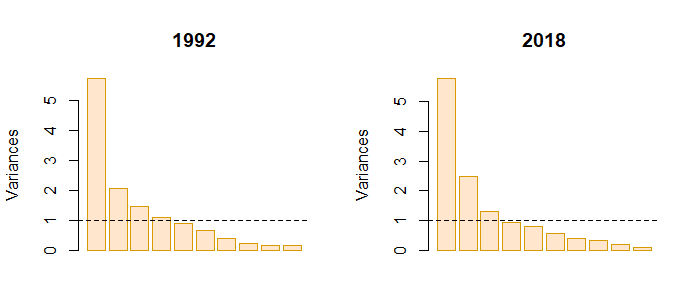

Figure 2: Scree plot of the principal components. The graphic representation of variances allows for easier selection of relevant components.

Analysing the scree plots, there are small differences in the eigenvalues of the components comparing the two years observed (Figure 2). If we use the Kaiser criterion, we see that only the first four (1992), respectively three (2018) components have eigenvalues greater than 1. But these components explain only 79.5% of the variation in the data for 1992 and 73.2% for 2018 and usually a cumulative proportion of at least 85%, that explain an acceptable level of variance, is obtained by the first five principal components. The fourth and fifth eigenvalues of the principal components in 2018 are only close to the value of 1. Therefore, values which are greater than 0.75 are considered as "strong". For an acceptable level of variance, we selected the first five principal components for analysis (Table 2).

Table 2: Summary of Principal Component Analysis (PCA) used for the selection of principal components. The components with a cumulative variance above 0.75 are considered "strong".

| 1992 | **PC(1)** | **PC(2)** | **PC(3)** | PC(4) | PC(5) | PC(6) | PC(7) | PC(8) | PC(9) | PC(10) | PC(11) | PC(12) | PC(13) |
| --- | --- | --- | --- | --- | --- | --- | --- | --- | --- | --- | --- | --- | --- |
| Std. dev. | 2.40 | 1.48 | 1.16 | 1.04 | 0.95 | 0.83 | 0.63 | 0.47 | 0.40 | 0.37 | 0.29 | 0.21 | 0.15 |
| Variance | 0.44 | 0.17 | 0.10 | 0.08 | 0.07 | 0.05 | 0.03 | 0.02 | 0.01 | 0.01 | 0.01 | 0.00 | 0.00 |
| Cumulative | 44.2% | 61.0% | 71.3% | 79.5% | 86.5% | 91.7% | 94.8% | 96.5% | 97.8% | 98.8% | 99.5% | 99.8% | 100.0% |
| 2018 | **PC(1)** | **PC(2)** | **PC(3)** | PC(4) | PC(5) | PC(6) | PC(7) | PC(8) | PC(9) | PC(10) | PC(11) | PC(12) | PC(13) |
| Std. dev. | 2.39 | 1.57 | 1.16 | 0.97 | 0.92 | 0.75 | 0.62 | 0.56 | 0.45 | 0.30 | 0.27 | 0.21 | 0.18 |
| Variance | 0.44 | 0.19 | 0.10 | 0.07 | 0.07 | 0.04 | 0.03 | 0.02 | 0.02 | 0.01 | 0.01 | 0.00 | 0.00 |
| Cumulative | 44.0% | 62.9% | 73.2% | 80.4% | 86.9% | 91.3% | 94.3% | 96.6% | 98.2% | 98.8% | 99.4% | 99.7% | 100.0% |

Table 3: Changes in the variances of the first five principal components in the analyzed time interval: 1992-2018.

|  | PC1 | PC2 | PC3 | PC4 | PC5 |
| --- | --- | --- | --- | --- | --- |
| 1992 | 44.2% | 61.0% | 71.3% | 79.5% | 86.5% |
| 2018 | 44.0% | 62.9% | 73.2% | 80.4% | 86.9% |
| change | -0.0018 | 0.0188 | 0.0190 | 0.0083 | 0.0042 |

Table 4: The first five values of the principal components for the variables $k_{1}$-$k_{13}$ in 1992 and 2018.

|  | Principal Component (1992) |  |  |  |  | Principal Component (2018) |  |  |  |  |
| --- | --- | --- | --- | --- | --- | --- | --- | --- | --- | --- |
| Variable | PC(1) | PC(2) | PC(3) | PC(4) | PC(5) | PC(1) | PC(2) | PC(3) | PC(4) | PC(5) |
| $k_{1}$ | 0.076 | -0.338 | -0.644 | 0.064 | -0.419 | 0.407 | -0.035 | -0.648 | -0.476 | -0.023 |
| $k_{2}$ | 0.000 | -0.588 | -0.175 | -0.713 | -0.042 | 0.128 | -0.613 | -0.013 | -0.614 | -0.084 |
| $k_{3}$ | -0.350 | 0.642 | -0.129 | -0.522 | 0.278 | -0.621 | 0.600 | -0.153 | -0.015 | 0.133 |
| $k_{4}$ | -0.711 | 0.557 | 0.089 | -0.113 | -0.240 | 0.338 | 0.843 | -0.279 | -0.047 | -0.158 |
| $k_{5}$ | -0.483 | 0.636 | 0.215 | 0.128 | -0.130 | 0.043 | 0.893 | 0.164 | -0.154 | -0.010 |
| $k_{6}$ | 0.233 | 0.487 | -0.708 | 0.142 | -0.096 | 0.094 | -0.384 | -0.671 | 0.528 | -0.060 |
| $k_{7}$ | 0.903 | -0.175 | 0.223 | 0.170 | 0.125 | -0.757 | -0.215 | 0.397 | -0.021 | 0.186 |
| $k_{8}$ | 0.935 | 0.212 | 0.051 | 0.064 | -0.022 | -0.936 | -0.031 | 0.045 | 0.001 | -0.210 |
| $k_{9}$ | 0.683 | 0.266 | 0.145 | -0.056 | -0.546 | -0.832 | 0.071 | -0.183 | -0.095 | -0.342 |
| $k_{10}$ | 0.806 | 0.355 | -0.322 | -0.054 | 0.186 | -0.841 | 0.045 | -0.286 | -0.037 | 0.366 |
| $k_{11}$ | 0.947 | 0.020 | 0.148 | 0.015 | 0.005 | -0.900 | -0.067 | -0.083 | -0.005 | -0.211 |
| $k_{12}$ | 0.697 | 0.175 | 0.313 | -0.433 | -0.323 | -0.871 | -0.030 | -0.011 | -0.018 | -0.395 |
| $k_{13}$ | 0.798 | 0.239 | -0.140 | -0.104 | 0.337 | -0.783 | 0.004 | -0.238 | -0.116 | 0.517 |

The scope of this analysis is to identify the directions (principal components) along which the variation in the data is the highest. As the first two components account for most of the variance in the date, to achieve this goal, the dimensionality of the multivariate data was reduced into two principal components, in order to be able to visualize them graphically. The two graphs were generated in R using the *ggplot2*, [*ggrepel*](https://CRAN.R-project.org/package=ggrepel), [*gridExtra*](https://CRAN.R-project.org/package=gridExtra) and [*readxl*](https://CRAN.R-project.org/package=readxl) packages (see `shrinking_cities.r` from supplemental material).

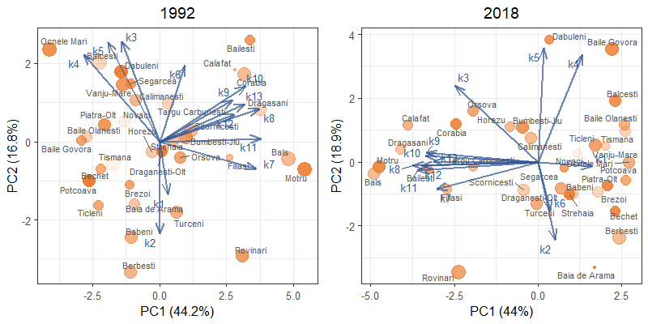

Figure 3: Principal Components Analysis of shrinkage indicators

The changes in population, especially the processes of ageing and shrinking, have a direct influence on the socio-economic dimension of settlements. As in most European countries, the ageing of the population is a phenomenon that characterizes almost all the settlements in Romania and will continue, but with different intensities; however, ageing greatly varies among the towns considered for analysis. The dimension of shrinking is given by the decrease in the number of inhabitants, which is better expressed by the decrease in the population density. The data indicated that, same as the ageing process, depopulation is another characteristic of the selected towns.

We used the RDC index to compare, at regional level, the dimension of ageing and shrinking of all 34 small towns located in Oltenia. Three time-intervals were considered (1992-2018 - past; 2018-2030 - future and 1992-2030 - overall) to show the overall and the future trend (Figure 4).

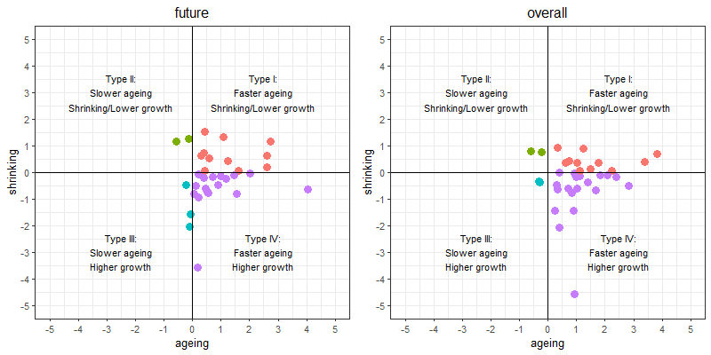

Figure 4: Future (2018-2030, left) and Overall (1992-2030, right) trends of Regional Demographic Change (RDC-type) for small towns in South-West Development Region of Oltenia

After examining the population trend for every town, we identified four categories, differentiated by ageing, population evolution and shrinking. This shows that some towns are more resilient to shrinkage than others, due to a combination of factors. However, there is clear evidence that a significant number of towns (about 40%) are shrinking, while 80% face a fast-ageing process of the population.

Table 5: Percent of towns according to the four types of RDC

| RDC type | Description | Future trend 2018-2030 |  | Overall trend 1992-2030 |  |
| --- | --- | --- | --- | --- | --- |
| I | Faster ageing. Shrinking/Lower growth | 11 towns | 32% | 11 towns | 32% |
| II | Slower ageing. Shrinking/Lower growth | 2 towns | 6% | 2 towns | 6% |
| III | Slower ageing. Higher growth | 4 towns | 12% | 2 towns | 6% |
| IV | Faster ageing. Higher growth | 17 towns | 50% | 19 towns | 56% |

Using the composite indicator (CSI) we computed the values for the beginning and present period and analysed the dimension of change for all 34 towns at demographic and social-economic levels for the future period (2030). The indicator includes all thirteen sub-indices (Table 1) considered important in the shrinking process of cities. The values of CSI for 1992 and 2018 were calculated using the following formula:

$$\label{formula}
CSI = \sum_{i=1}^{n}\frac{k_{i}-min\left(k_{i}\right)}{n\left(max\left(k_{i}\right)-min\left(k_{i}\right)\right)} \tag{1}$$

where:

| $n$: | subindicator count |
| --- | --- |
| $k_{i}$: selected subi | ndicator |
| $min\left(k_{i}\right)$: minimum value | of subindicator |
| $max\left(k_{i}\right)$: maximum value | of subindicator |

Table 6: The computed values of CSI for each town, showing shrinkage in 1992, 2018 and the 2030 forecast.

[output not shown]

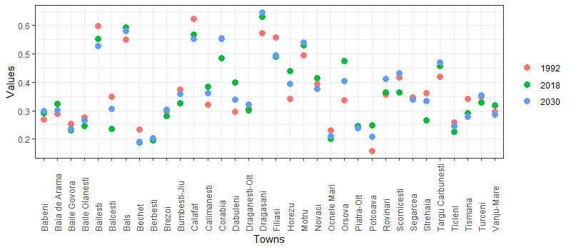

Figure 5: Variation of CSI values for the reference period

## 4 Discussions

As we initially calculated the RDC index for all 34 towns to analyse the dimension of shrinking, we deem necessary to use a more complex index to include economic and social dimensions. Tivig et al. (2008) analyses the dimension of shrinking using only demographic indices, classifying cities in four categories. However, the scientific literature considers the topic of shrinking cities as a more complex process, which involves social and economic factors (Bernt et al. 2012; Wolff and Wiechmann 2014; Martinez-Fernandez et al. 2015).

Besides the general factors, local features also contribute to the shrinking process of cities, especially for smaller ones. Therefore, we deem necessary to also use another, more complex, composite indicator. After comparing the results, we concluded that only six towns undergo a clear shrinking process, falling into the category of persistent shrinkage, while eighteen have a moderate or slow evolution toward shrinking (recent or mild shrinkage). There are also ten settlements that had a linear, almost stagnant, evolution for the entire reference period with the same future trend (Figure 6).

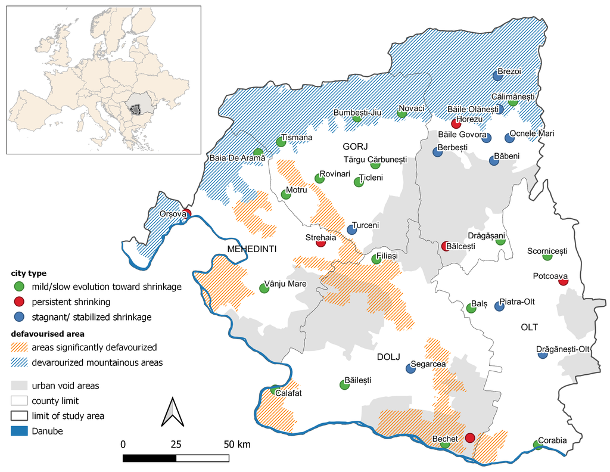

Figure 6: City types according to CSI

According to CSI values the towns can be classified in three categories: persistent shrinkage, a mild evolution towards shrinkage and stagnant shrinkage. The first category includes only 6 towns, which is less than a fifth of the analysed towns, and except for Orșova, they did not benefit during the communist period from any state-owned flagship companies and did not have any significant industrial base. This category varies largely in terms of population size, population loss, economic activities and rural/urban characteristics. The smaller and more rural in character the town, the greater the pressure on shrinkage is. Just as in other regions, the regional and local economic restructuring alter the urban communities (Jucu et al. 2016).

A mild/slow evolution toward shrinkage characterizes the towns of Băilești, Bechet, Calafat, Tismana, Bumbești, Novaci, Țicleni, Târgu Cărbunești, Filiași, Motru, Rovinari, Baia de Aramă, Vânju Mare, Balș, Corabia, Scornicești, Călimănești and Drăgășani. There is a diversity of different town types (resourced-based mining towns, old ports, rural small towns, some tourism activities), scattered throughout the entire region, testifying that there are multiple factors causing shrinkage. Few of these towns have managed to keep their industrial activities due to the strategic importance of their power plants for the production of electricity. Most of them did not succeed to foster any new economic activities, nor modernise traditional branches, so there were no major new investments since the 1980s. This situation may be partially attributed to the towns location and poor accessibility, but also lack of entrepreneurial culture and poor administration that was hardly able to cope with the economic decline and transition to the market economy.

A stagnant/stabilized shrinkage was noted for ten towns (Figure 6). Some of these towns have kept and developed some forms of tourism activities (holiday homes, private camps, accommodation and leisure facilities), benefiting from considerable investments following various programmes financed by the EU for fostering the tourism sector.

Small towns that relied heavily on agriculture, forestry or mining activities will continue to be affected by shrinking, which will definitely put a stain on their physical and social structure, the need for viable alternatives to smart shrinkage being of utmost importance.

This analysis provides empirical confirmation that many small towns in Oltenia are in fact shrinking, despite different economic and demographic background, and that mainly the demographic indicators (population decrease, out-migration and ageing), followed by economic ones, are the most important factors for urban shrinkage in the region. However, these towns do not only face loses of population, but also a mismatch between the physical urban structure and the population needs.

What are the main causes for shrinking in the case of small and medium towns in Oltenia? After analysing the situation in other European countries, we can definitely say that the experience of this region has some specifics, as the urban shrinkage is not caused by suburbanization and to a larger extent, neither by deindustrialization. In 1992, most (3/4) of the small and medium-small towns in the region had a location quotient of industry below the urban average of 1.029 (Popescu 2014), which might in part explain this situation. Moreover, these towns were ranked much lower in the urban hierarchy and had limited economic options, hosting mainly local resource-based industries.

Shrinking is rather caused by the overlapping of simultaneous demographic processes - out-migration, drops in birth rates, ageing (which leads to population decline) and economic difficulties (loss of jobs, lack of private companies, lack of entrepreneurial culture, heavy reliance on agriculture and subsidies from the government).

## 5 Conclusions

During the last decade, the issue of *shrinking cities* is pervasive for the research interest of academics and the political discourse of many countries. Unfortunately, despite the evident urban decline of small Romanian towns, from both the economic and demographic perspective during the last 3 decades, the politicians and authorities seem to miss the extent of this phenomenon, which has become rather common in Romania and Oltenia region as well.

The decrease in size of the population, the increase of the mean age and the ageing of the population has repercussions on the economy by reducing the labour force. It also influences the values of social criteria directly influencing the number of households, number of schools or the school population. The evolution of settlements may also correlate with the local factors like their proximity to a disfavoured area or to a dominantly rural area.

The thirteen indicators taken into consideration reflect demographic, economic and social aspects that point to vulnerabilities and lack of adaptability in Romanian shrinking cities (Bănică et al. 2017) rather than to aspects of resilience capacity. Also, the indicators were thought-out to be used as a base-model in analysing the dimension of a complex phenomenon like urban shrinking for other case studies which may include larger urban settlements. Of course, depending on other factors, the indicators considered for analysis may be modified. The three types of shrinkage testify for the existence of different patterns (rhythms, trajectories, effects), which means that there is no miracle solution that could be applied to all the towns.

What are the alternatives for smart urban shrinkage? Considering that shrinking is seldom a rapid process, and it rather takes place over generations, providing the luxury of time to adapt the planning and designing process, the condition of shrinking does not have to be a terminal diagnosis for a small town (Fugate 2007). Numerous studies point to the need for the involvement of communities to promote the principle of re-growing smaller and more sustainable. Another solution might focus on the assumed decision for turning to rural, considering the opportunity of using European funds and projects for rural development.

There are no policies for shrinking cities at national or regional level, despite the numerous strategies for sustainable development, which fail to acknowledge the extent and severity of this phenomenon, affecting mainly small and medium-size towns. All the strategies for development seem to disregard the context and consequences of urban shrinkage, choosing to focus instead mainly on economic growth, which seems to evade almost all these towns during the last decades. These towns lack any capacity to cope with the consequences of urban shrinkage, their development strategies lacking both awareness and preparedness to actively respond to this issue.

## 6 Author contribution

C.V. and L.P. conceived and wrote the content and the R code of the study. A.C. debugged and reviewed the R code; also prepared the LaTeX source.

### 6.1 Supplementary materials

Supplementary materials are available in addition to this article. It can be downloaded at RJ-2022-004.zip

### 6.2 CRAN packages used

ggplot2, ggrepel, gridExtra, readxl

### 6.3 CRAN Task Views implied by cited packages

ChemPhys, NetworkAnalysis, Phylogenetics, Spatial, TeachingStatistics

M. Agirre-Maskariano. Politiques urbaines pour la mise en récit d’une ville moyenne périphérisée en décroissance : L’exemple de Montluçon. *Belgeo. Revue belge de géographie*, (3): 2019. URL http://journals.openedition.org/belgeo/35087 [online; last accessed August 25, 2020]. Number: 3 Publisher: National Committee of Geography of Belgium / Société Royale Belge de Géographie.

I. Audirac. Shrinking cities in the fourth urban revolution. In *Shrinking cities: International perspectives and policy implications*, 2014. Routledge.

A. Bănică, M. Istrate and I. Muntele. Challenges for the resilience capacity of Romanian shrinking cities. *Sustainability*, 9(12): 2289, 2017. URL https://www.mdpi.com/2071-1050/9/12/2289 [online; last accessed August 26, 2020]. Number: 12 Publisher: Multidisciplinary Digital Publishing Institute.

T. Barry. Collections in R: Review and proposal. *The R Journal*, 10(1): 455, 2018. URL https://journal.r-project.org/archive/2018/RJ-2018-037/index.html [online; last accessed September 20, 2020].

R. Beauregard A. Shrinking cities in the United States in historical perspective: A research note. In *Shrinking cities: International perspectives and policy implications*, pages. 49–57 2013. Routledge. URL https://books.google.com/books/about/Shrinking_Cities.html?hl=ro&id=NWhtAAAAQBAJ [online; last accessed August 20, 2020].

M. Bernt, M. Cocks, C. Couch, K. Großmann, A. Haase and D. Rink. Policy response, governance and future directions. 2012. URL https://www.ufz.de/export/data/400/39031_ResearchBrief2_.pdf [online; last accessed August 25, 2020].

M. Bontje. Facing the challenge of shrinking cities in East Germany: The case of Leipzig. *GeoJournal*, 61: 13–21, 2004. URL https://link.springer.com/content/pdf/10.1007/s10708-005-0843-2.pdf.

G. Breckenfeld. Coping with city shrinkage. *Civil Engineering—ASCE*, 48(11): 112–113, 1978. URL https://cedb.asce.org/CEDBsearch/record.jsp?dockey=0027669 [online; last accessed August 20, 2020]. Publisher: ASCE.

N. Cauchi-Duval, F. Cornuau and M. Rudolph. La décroissance urbaine en France : les effets cumulatifs du déclin. *Metropolitique*, 11, 2017. URL https://www.metropolitiques.eu/IMG/pdf/met-cauchiduval-cornuau-rudolph.pdf.

E. Cunningham-Sabot, I. Audirac, S. Fol and C. Martinez-Fernandez. Theoretical approaches of "shrinking cities". In *Shrinking cities: International perspectives and policy implications*, pages. 30–46 2014. Routledge.

J. N. Fugate. Shrinking gracefully: Looking for effective planning and design approaches for small town America. 2007. URL https://dspace.mit.edu/handle/1721.1/39846 [online; last accessed September 3, 2020]. Accepted: 2008-01-10T14:25:30Z Journal Abbreviation: Looking for effective planning and design approaches for small town America.

X. Gan, I. C. Fernandez, J. Guo, M. Wilson, Y. Zhao, B. Zhou and J. Wu. When to use what: Methods for weighting and aggregating sustainability indicators. *Ecological Indicators*, 81: 491–502, 2017. URL http://www.sciencedirect.com/science/article/pii/S1470160X17303357 [online; last accessed April 14, 2020].

R. Göb. Die schrumpfende Stadt. *Archiv für Kommunalwissenschaften*, 16: 149–177, 1977.

M. H. Guimarães, A. P. Barreira and T. Panagopoulos. Shrinking cities in Portugal – where and why. *Revista Portuguesa de Estudos Regionais*, 40: 23–41, 2015. URL https://www.redalyc.org/pdf/5143/514351600002.pdf.

A. Haase, M. Bernt, K. Großmann, V. Mykhnenko and D. Rink. Varieties of shrinkage in European cities. *European Urban and Regional Studies*, 23(1): 86–102, 2016. URL https://journals.sagepub.com/doi/abs/10.1177/0969776413481985 [online; last accessed August 26, 2020]. Publisher: SAGE PublicationsSage UK: London, England.

A. Haase, D. Rink, K. Grossmann, M. Bernt and V. Mykhnenko. Conceptualizing urban shrinkage. *Environment and Planning A: Economy and Space*, 46(7): 2014. URL https://journals.sagepub.com/doi/abs/10.1068/a46269 [online; last accessed August 20, 2020]. Publisher: SAGE PublicationsSage UK: London, England.

M. D. Hartt. How cities shrink: Complex pathways to population decline. *Cities*, 75: 38–49, 2018. URL https://linkinghub.elsevier.com/retrieve/pii/S0264275116302943 [online; last accessed August 26, 2020].

N. Jollands. The usefulness of aggregate indicators in policy making and evaluation: A discussion with application to eco-efficiency indicators in New Zealand. 2003. Accepted: 2003-11-04 Last Modified: 2019-01-22 Publisher: The Australian National University.

I. T. Jolliffe and J. Cadima. Principal component analysis: A review and recent developments. *Philosophical Transactions of the Royal Society A: Mathematical, Physical and Engineering Sciences*, 374(2065): 20150202, 2016. URL https://royalsocietypublishing.org/doi/full/10.1098/rsta.2015.0202 [online; last accessed April 14, 2020]. Publisher: Royal Society.

I. S. Jucu, R. Creţan and F. Timofte. Economic restructuring and contrasting urban patterns in Romanian post-socialist municipalities: The experiences of Timiş county, Romania. *Review of Historical Geography and Toponomastics*, XI(21): 79–96, 2016. URL https://geografie.uvt.ro/wp-content/uploads/2015/06/11_JUCU_CRETAN_FABIAN.pdf.

I. S. Jucu and S. Pavel. Post-communist urban ecologies of Romanian medium-sized towns. *Forum geografic*, XVIII(2): 170–183, 2019. URL http://forumgeografic.ro/ro/2019/2577/ [online; last accessed September 16, 2020].

A. Kassambara. *R graphics essentials for great data visualization.* 1st ed CreateSpace Independent Publishing Platform, 2017.

S. Lauf, D. Haase and B. KleinschmitcaTechnische. The effects of growth, shrinkage, population aging and preference shifts on urban development — a spatial scenario analysis of Berlin, Germany. *Land Use Policy*, 52: 240–254, 2016. URL https://www.sciencedirect.com/science/article/abs/pii/S0264837715004135 [online; last accessed August 28, 2020]. Publisher: Pergamon.

R. Lovelace, J. Nowosad and J. Muenchow. *Geocomputation with R.* Chapman & Hall/CRC, 2019.

A. Mallach, A. Haase and K. Hattori. The shrinking city in comparative perspective: Contrasting dynamics and responses to urban shrinkage. *Cities*, 69: 102–108, 2017. URL https://linkinghub.elsevier.com/retrieve/pii/S0264275116303110 [online; last accessed August 25, 2020].

C. Martinez-Fernandez, T. Weyman, S. Fol, I. Audirac, E. Cunningham-Sabot, T. Wiechmann and H. Yahagi. Shrinking cities in Australia, Japan, Europe and the USA: From a global process to local policy responses. *Progress in Planning*, 2015. DOI 10.1016/j.progress.2014.10.001.

M. Nardo, M. Saisana, A. Saltelli and S. Tarantola. Tools for composite indicators building. 134, 2005.

A. Nelle, K. Großmann, D. Haase, S. Kabisch, D. Rink and M. Wolff. Urban shrinkage in Germany: An entangled web of conditions, debates and policies. *Cities*, 69: 116–123, 2017. URL https://linkinghub.elsevier.com/retrieve/pii/S026427511630227X [online; last accessed August 25, 2020].

OECD. *Handbook on constructing composite indicators: Methodology and user guide.* OECD Publishing, 2008.

P. Oswalt and T. Rieniets. *Atlas of shrinking cities.* Hatje Cantz, 2006. URL https://www.research-collection.ethz.ch/handle/20.500.11850/25547 [online; last accessed August 25, 2020]. Accepted: 2018-03-29T10:36:31Z Journal Abbreviation: Atlas der schrumpfenden Städte.

K. Pallagst. Viewpoint: The planning research agenda: Shrinking cities — a challenge for planning cultures. *The Town Planning Review*, 81(5): i–vi, 2010. URL https://www.jstor.org/stable/27975967 [online; last accessed August 20, 2020].

L. C. Paul, L. Saha, A. A. Suman and N. U. Mondal. Methodological Analysis of Principal Component Analysis Method. *International Journal of Scientific & Engineering Research*, 4(3): 9, 2013.

I. Păun Constantinescu. *Shrinking cities in Romania.* 2019th ed DOM Publishers, 2019. URL https://dom-publishers.com/products/shrinking-cities-in-romania [online; last accessed August 25, 2020].

I. Păun Constantinescu. Shrinking cities în România. O abordare contemporană a contracției și delinului urban. 2013. URL https://www.uauim.ro/f/doctorat/sustineri_teze/REZUMAT.pdf [online; last accessed August 26, 2020].

G. Pirisi, A. Trócsányi and B. Makkai. Between shrinking and blooming: The crossroad of small towns’ urbanisation in Hungary. *Annales Universitatis Paedagogicae Cracoviensis Studia Geographica*, 8 Small Towns’ Development Problems: 12–28, 2015. URL http://cejsh.icm.edu.pl/cejsh/element/bwmeta1.element.desklight-6a8a7af9-e7ee-4f2d-a69a-3c35dbeda870 [online; last accessed September 2, 2020]. Publisher: Instytut Geografii Uniwersytetu Pedagogicznego im. Komisji Edukacji Narodowej w Krakowie.

N. Pollesch and V. H. Dale. Applications of aggregation theory to sustainability assessment. *Ecological Economics*, 114: 117–127, 2015. URL http://www.sciencedirect.com/science/article/pii/S0921800915000968 [online; last accessed April 10, 2020].

C. Popescu. Deindustrialization and urban shrinkage in Romania. What lessons for the spatial policy? *Transylvanian Review of Administrative Sciences*, 10(42): 181–202, 2014. URL https://www.rtsa.ro/tras/index.php/tras/article/view/97 [online; last accessed August 26, 2020]. Number: 42.

D. Reckien and C. Martinez-Fernandez. Why do cities shrink? *European Planning Studies*, 19(8): 1375–1397, 2011. URL https://www.tandfonline.com/doi/abs/10.1080/09654313.2011.593333 [online; last accessed August 25, 2020]. Publisher: Routledge.

D. Rink, A. Haase, M. Bernt and K. Großmann. Addressing urban shrinkage across Europe – challenges and prospects. 24, 2010. URL https://www.ufz.de/export/data/400/39003_D9_Research_Brief_FINAL14223.pdf.

M. Saisana and S. Tarantola. State of the art. Report on current methodologies and practices for composite indicator development. 72, 2002.

A. M. Schoenberg and D. L. Constantin. Urban shrinkage in Romania: Scope and determinants. In *Shrinking Cities*, 1st ed 2014. Routledge. ISBN 978-0-203-07976-8. Num Pages: 14.

S. Sharma. *Applied multivariate techniques.* 1st ed Wiley, 1996.

I.-V. Stoica, A. F. Tulla, D. Zamfir and A.-I. Petrișor. Exploring the Urban Strength of Small Towns in Romania. *Social Indicators Research*, 152(3): 843–875, 2020a. URL http://link.springer.com/10.1007/s11205-020-02465-x [online; last accessed August 5, 2021].

I.-V. Stoica, D. Zamfir and L. C. Săftoiu. Small towns in Romania: The road from the urban dream to the rural reality. In *New Rural Geographies in Europe: Actors, Processes, Policies*, Eds A. Steinführer, A.-B. Heindl, U. Grabski-Kieron and A. Reichert-Schick 2020b. LIT Verlag. ISBN 978-3-643-91302-9. Google-Books-ID: YqAeEAAAQBAJ.

M. Syrovátka and M. Schlossarek. Measuring development with inequality: How (should) aggregate indicators of development account for inequality? *Ecological Economics*, 164: 106320, 2019. URL https://linkinghub.elsevier.com/retrieve/pii/S0921800918307274 [online; last accessed April 14, 2020].

T. Tivig, K. Frosch and S. Kühntopf. Mapping regional demographic change and regional demographic location risk in Europe laboratory demographic change. 2008.

I. Turok and V. Mykhnenko. The trajectories of European cities, 1960–2005. *Cities*, 24(3): 165–182, 2007. URL https://www.sciencedirect.com/science/article/abs/pii/S0264275107000212 [online; last accessed August 25, 2020]. Publisher: Pergamon.

Urban Audit. State of European cities report. Adding value to the European Urban Audit. 2007. URL https://ec.europa.eu/regional_policy/sources/docgener/studies/pdf/urban/stateofcities_2007.pdf [online; last accessed August 25, 2020].

H. Wickham. *ggplot2: Elegant graphics for data analysis.* Springer-Verlag New York, 2016. URL https://ggplot2.tidyverse.org.

T. Wiechmann. Types of shrinking cities–Introductive Notes on a Global Issue. In *International Symposium "Coping with City Shrinkage and Demographic Change–Lessons from around the Globe"*, 2006. Dresden.

T. Wiechmann. What are the problems of shrinking cities? Lessons learned from an international comparison. *The Future of Shrinking Cities-Problems, Patterns and Strategies of Urban Transformation in a Global Context*, 5–16, 2007. URL https://www.nature.com/articles/nmeth.4346 [online; last accessed April 10, 2020].

T. Wiechmann and M. Bontje. Responding to tough times: Policy and planning strategies in shrinking cities. *European Planning Studies*, 23(1): 1–11, 2015. URL https://www.tandfonline.com/doi/abs/10.1080/09654313.2013.820077 [online; last accessed August 25, 2020]. Publisher: Routledge.

T. Wiechmann and M. Wolff. Urban shrinkage in a spatial perspective – operationalization of shrinking cities in Europe 1990 - 2010. *AESOP - ACSP Joint Congress*, 21, 2013.

P. Wirth, V. Elis, B. Müller and K. Yamamoto. Peripheralisation of small towns in Germany and Japan – dealing with economic decline and population loss. *Journal of Rural Studies*, 47: 62–75, 2016. URL https://www.sciencedirect.com/science/article/abs/pii/S0743016716301851 [online; last accessed August 28, 2020]. Publisher: Pergamon.

M. Wolff, S. Fol, H. Roth and E. Cunningham-Sabot. Shrinking Cities, villes en décroissance : une mesure du phénomène en France. *Cybergeo : European Journal of Geography*, 2013. URL http://journals.openedition.org/cybergeo/26136 [online; last accessed August 25, 2020]. Publisher: CNRS-UMR Géographie-cités 8504.

M. Wolff and T. Wiechmann. Indicators to measure shrinking cities. In *A conceptual framework for shrinking cities*, Eds C. Martinez-Fernandez, S. Fol and T. Weyman 2014. Researchgate. URL https://www.researchgate.net/publication/270339860_Indicators_to_measure_shrinking_cities [online; last accessed August 28, 2020].